# EAT: Efficiency Analysis Trees

Center of Operations Research

2021-04-06

## A brief introduction to production theory field

This vignette is intended to know the main functions of the `eat` package. [Efficiency Analysis Trees](https://www.sciencedirect.com/science/article/pii/S0957417420306072) is an algorithm that estimates a production frontier in a data-driven environment by adapting regression trees. In this way, techniques from the field of **machine learning** are incorporated into solving problems in the field of **production theory**. From the latter, the following terminology is introduced.

Let us consider $n$ Decision Making Units (DMUs) to be evaluated. $DMU_i$ consumes $\textbf{x}_i = (x_{1i}, ...,x_{mi}) \in R^{m}_{+}$ amount of inputs for the production of $\textbf{y}_i = (y_{1i}, ...,y_{si}) \in R^{s}_{+}$ amount of outputs. The relative efficiency of each DMU in the sample is assessed with reference to the so-called production possibility set or technology, which is the set of technically feasible combinations of $(\textbf{x, y})$. It is defined in general terms as:

$$\begin{equation}
\Psi = \{(\textbf{x, y}) \in R^{m+s}_{+}: \textbf{x} \text{ can produce } \textbf{y}\}
\end{equation}$$

Monotonicity (free disposability) of inputs and outputs is assumed, meaning that if $(\textbf{x, y}) \in \Psi$, then $(\textbf{x', y'}) \in \Psi$, as soon as $\textbf{x'} \geq \textbf{x}$ and $\textbf{y'} \leq \textbf{y}$. Often convexity of $\Psi$ is also assumed. The efficient frontier of $\Psi$ may be defined as $\partial(\boldsymbol{\Psi}) := \{(\boldsymbol{x,y}) \in \boldsymbol{\Psi}: \boldsymbol{\hat{x}} < \boldsymbol{x}, \boldsymbol{\hat{y}} > \boldsymbol{y} \Rightarrow (\boldsymbol{\hat{x},\hat{y}}) \notin \boldsymbol{\Psi} \}$. Technical inefficiency is defined as the distance from a point that belongs to $\Psi$ to the production frontier $\partial(\Psi)$. For a point located inside $\Psi$, it is evident that there are many possible paths to the frontier, each associated with a different technical inefficiency measure.

## Summary of eat functions

| Purpose | Function.name | Usage |
| --- | --- | --- |
| Model | EAT | Apply Efficiency Analysis Trees technique to a data set. Return an EAT object. |
|  | RFEAT | Apply Random Forest + Efficiency Analysis Trees technique to a data set. Return a RFEAT object. |
| Summarize | print | For an EAT object: print the tree structure of an EAT model. For a RFEAT object: print a brief summary of a RFEAT model. |
|  | summary | For an EAT object: return a summary for the leaf nodes, general information about the model and the error and threshold for each split and surrogate split. |
|  | size | Return the number of leaf nodes for an EAT model. |
|  | frontier.levels | Return the frontier output levels at the leaf nodes for an EAT model. |
|  | descrEAT | Return measures of centralization and dispersion with respect to the outputs for the nodes of an EAT model. |
| Tune | bestEAT | Tune an EAT model. |
|  | bestRFEAT | Tune a RFEAT model. |
| Graph | frontier | Plot the estimated frontier through an EAT model in a low dimensional scenario (FDH estimated frontier is optional). |
|  | plotEAT | Plot the tree structure of an EAT model. |
|  | plotRFEAT | Shows a line graph with the OOB error on the y-axis, calculated from a forest made up of k trees (x-axis). |
| Calculate efficiency scores | efficiencyEAT | Calculate DMU efficiency scores through an EAT (and optionally through a FDH) model. |
|  | efficiencyCEAT | Calculate DMU efficiency scores through a convex EAT (and optionally through a DEA) model. |
|  | efficiencyRFEAT | Calculate DMU efficiency scores through a RFEAT (and optionally through a FDH) model. |
| Graph efficiency scores | efficiencyDensity | Graph a density plot for a data frame of efficiency scores (EAT, FDH, CEAT, DEA and RFEAT are available). |
|  | efficiencyJitter | Graph a jitter plot for a vector of efficiency scores calculated through an EAT model (EAT or CEAT scores are accepted). |
| Predict | predictEAT | Predict the output through an EAT model. |
|  | predictRFEAT | Predict the output through a RFEAT model. |
| Rank | rankingEAT | Calculate variable importance scores through an EAT model. |
|  | rankingRFEAT | Calculate variable importance scores through a RFEAT model. |

## The PISAindex database

The `PISAindex` database is included as a data object in the `eat` library and is employed to exemplify the package functions. On the one hand, the inputs correspond to 13 variables that define the socioeconomic context of a country, by means of a score in the range [1-100], except for the Gross Domestic Product by Purchasing Power Parity, which is measured in thousands of dollars. All of them have been obtained from the [Social Progress Index](https://www.socialprogress.org/). On the other hand, the performance of each country in the PISA exams is measured by the average score of its schools in the disciplines of Science, Reading and Mathematics which have been collected from [PISA 2018 Results](https://www.oecd.org/pisa/Combined_Executive_Summaries_PISA_2018.pdf).

The following variables are collected for 72 countries that take the PISA exam:

- **Country**, **Continent** and a 3-letter code that identifies the country following the ISO 3166 ALPHA-3 as rownames.
- *Outputs* :
  - **S_PISA** : mean score on the PISA exam in Science.
  - **R_PISA** : mean score on the PISA exam in Reading.
  - **M_PISA** : mean score on the PISA exam in Mathematics.
- *Inputs* :
  - Basic Human Needs field :
    - **NBMC** : Nutrition and Basic Medical Care.
    - **WS** : Water and Sanitation.
    - **S** : Shelter.
    - **PS** : Personal Safety.
  - Foundations of Well-being field :
    - **ABK** : Access to Basic Knowledge.
    - **AIC** : Access to Information and Communications.
    - **HW** : Health and Wellness.
    - **EQ** : Environmental Quality.
  - Opportunity field :
    - **PR** : Personal Rights.
    - **PFC** : Personal Freedom and Choice.
    - **I** : Inclusiveness.
    - **AAE** : Access to Advanced Education.
  - **GDP_PPP** : Gross Domestic Product based on Purchasing Power Parity.

The `eat` package is applied with the following purposes: (1) to create homogeneous groups of countries in terms of their socioeconomic characteristics (Basic Human Needs, Foundations of Well-being, Opportunity and GDP PPP per capita) and subsequently to know what maximum PISA score is expected in one or more specific disciplines for each of these groups; (2) to know which countries exercise best practices and which of them do not obtain a performance according to their socioeconomic level; and (3) to know what variables are more relevant in obtaining efficient levels of output.

```r
# We save the seed for reproducibility of the results
set.seed(120)
```

```r
library(eat)
data("PISAindex")
```

## Modeling a scenario with an input and an output. Plotting the frontier

### EAT()

The `EAT` function is the centerpiece of the `eat` library. `EAT` performs a regression tree based on CART methodology under a new approach that guarantees obtaining a frontier as an estimator that fulfills the property of free disposability. This new technique has been baptized as Efficiency Analysis Trees. The development of the functions contained in the `eat` library has been designed so that even true R novices can use the library easily. The minimum arguments of the function are the data (`data`) containing the study variables, the indexes of the predictor variables or inputs (`x`) and the indexes of the predicted variables or outputs (`y`). Additionally, the `numStop`, `fold`, `max.depth` and `max.leaves` arguments are included for those more experienced users in the fields of machine learning and tree-based models. Modifying these four allows obtaining different frontiers and therefore selecting the one that best suits the needs of the analysis.

- `numStop` refers to the minimum number of observations in a node to be divided and is directly related to the size of the tree. The higher the value of `numStop`, the smaller the size of the tree.
- `fold` refers to the number of parts in which the dataset is divided to apply the cross-validation technique. Variations in the `fold` argument are not directly related to the size of the tree.
- `max.depth` limits the number of nodes between the root node and the furthest leaf node (root not included). When this argument is introduced, the typical process of growth-pruning is not carried out. In this case, the tree is allowed to grow to the required depth.
- `max.leaves` determines the maximum number of leaf nodes. As in `max.depth`, the process of growth-pruning is not performed. In this respect, the tree grows until the required number of leaf nodes is reached, and then, the tree is returned.

Note that including the arguments `max.depth` or `max.leaves` hyperparameters reduce the computation time by eliminating the pruning procedure. If both are included at the same time, a warning message is displayed and only `max.depth` is used.

The error of a given node $t$ is measured as the prediction error at the node $t$ over the total number of observations:
$$\begin{equation}
R(t) = \frac{n(t)}{N} \cdot MSE(t) = \frac{1}{N} \cdot \sum_{(x_i,y_i)\in t}(y_i - \hat{y}(t))^2
\end{equation}$$

The impurity of a tree $T$ is measured as the sum of the impurities for each leaf node
$$\begin{equation}
R(T) = \sum_{i = 1}^{\widetilde{T}}R(t_i),
\end{equation}$$

where $\widetilde{T}$ is the set of leaf nodes for the tree $T$.

The function returns an `EAT` object.

```r
EAT(data, x, y,
    fold = 5,
    numStop = 5,
    max.depth = NULL,
    max.leaves = NULL,
    na.rm = TRUE)
```

```r
single_model <- EAT(data = PISAindex,
                    x = 15, # input
                    y = 3) # output
```

`print()` returns the tree structure for an `EAT` object where:

- `y` : vector of predictions.
- `R` : error at the node.
- `n(t)` : number of DMUs at the node.
- `input name < / >= s` represents the division of the space.
- `<*>` indicates a leaf node.

```r
print(single_model)
```

```
 [1] y: [ 551 ] || R: 11507.5 n(t): 72

 |  [2] PFC < 77.2 --> y: [ 478 ] || R: 2324.47 n(t): 34

 |   |  [4] PFC < 65.45 --> y: [ 428 ] <*> || R: 390.17 n(t): 16

 |   |  [5] PFC >= 65.45 --> y: [ 478 ] <*> || R: 637.08 n(t): 18

 |  [3] PFC >= 77.2 --> y: [ 551 ] <*> || R: 2452.83 n(t): 38

<*> is a leaf node
```

`summary()` returns the following information of an `EAT` object:

- `Formula` : outputs ~ inputs
- `Summary for leaf nodes` where:
  - `id` : leaf node index.
  - `n(t)` : number of DMUs at the leaf node.
  - `%` : proportion of DMUs at the leaf node.
  - As many columns as `output names` with the corresponding predictions for the leaf nodes.
  - `R(t)` : error at the leaf node.
- `Tree` where:
  - `Interior nodes` : number of interior nodes.
  - `Leaf nodes` : number of leaf nodes.
  - `Total nodes` : total number of nodes (interior nodes + leaf nodes).
  - `R(T)` : error at the model.
  - `numStop` : numStop hyperparameter value.
  - `fold` : fold hyperparameter value.
  - `max.depth` : max.depth hyperparameter value.
  - `max.leaves` : max.leaves hyperparameter value.
- `Primary & surrogate splits` where:
  - `Node A --> {B, C}` indicates that the node A is split into the left child node B and the right child node C.
  - `variable --> {R: , s: }` represents the division of the space with its error and threshold.
  - `Surrogate splits` indicates the best possible split for each variable that has not been used to divide the node. This is expressed as `variable --> {R: , s: }` where `R` is the error at the node and `s` the threshold. Results are displayed in descending order by their `R` value. In the case of a single input, the surrogate splits do not appear.

```r
summary(single_model)
```

```
  Formula:  S_PISA ~ PFC

 # ========================== #
 #   Summary for leaf nodes   #
 # ========================== #

 id n(t)  % S_PISA    R(t)
  3   38 53    551 2452.83
  4   16 22    428  390.17
  5   18 25    478  637.08

 # ========================== #
 #            Tree            #
 # ========================== #

 Interior nodes: 2
     Leaf nodes: 3
    Total nodes: 5

           R(T): 3480.08
        numStop: 5
           fold: 5
      max.depth:
     max.leaves:

 # ========================== #
 # Primary & surrogate splits #
 # ========================== #

 Node 1 --> {2,3} || PFC --> {R: 4777.31, s: 77.2}

 Node 2 --> {4,5} || PFC --> {R: 1027.25, s: 65.45}
```

`size()` returns the number of leaf nodes of an `EAT` model:

```r
size(single_model)
```

```
The number of leaf nodes of the EAT model is: 3
```

`frontier.levels()` returns the frontier levels of the outputs at the leaf nodes:

```r
frontier.levels(single_model)
```

```
The frontier levels of the outputs at the leaf nodes are:
```

```
  S_PISA
1    551
2    428
3    478
```

`descrEAT()` returns a list with measures of centralization and dispersion, as well as the root mean square error (RMSE) for each node. In multioutput scenarios, the measurements are shown for each output. In case of a single output, the result of the function is a data frame. The following information is obtained:

- `Node`: node index.
- `n(t)`: number of DMUs.
- `%`: proportion of DMUs.
- `mean`: mean.
- `var`: variance.
- `sd`: standard deviation.
- `min`: minimum.
- `Q1`: first quantile.
- `median`: median.
- `Q3`: third quantile.
- `max`: maximum.
- `RMSE`: root mean square error.

```r
descriptiveEAT <- descrEAT(single_model)

descriptiveEAT
```

```
  Node n(t)   %   mean     var    sd min     Q1 median     Q3 max   RMSE
1    1   72 100 455.06 2334.59 48.32 336 416.75  466.0 495.25 551 107.27
2    2   34  47 416.88 1223.02 34.97 336 397.25  415.5 435.75 478  70.16
3    3   38  53 489.21  851.95 29.19 419 478.00  494.0 504.50 551  68.17
4    4   16  22 394.62  684.65 26.17 336 381.50  398.0 414.00 428  41.90
5    5   18  25 436.67  889.29 29.82 386 415.25  433.5 468.00 478  50.48
```

Additionally, `EAT_object[["tree"]][[id_node]]` or `EAT_object$tree[[id_node]]` returns a `list` that allows knowing the characteristics of a given node in greater detail. The elements that define a node are the following:

- `id` : node index.
- `F` : father node index.
- `SL` : left child node index.
- `SR` : right child node index.
- `index` : set of indexes corresponding to the observations in a node.
- `varInfo` : list containing the error of the left node, the error of the right node and the threshold of the best split for each input.
- `R` : error at the node.
- `xi` : index of the variable that produces the split in a node.
- `s` : threshold of the variable `xi` by which the split takes place.
- `y` : value(s) of the predicted variable(s) in a node.
- `a` : lower bound of the given node.
- `b` : upper bound of the given node.

Note that:

- The node with index 1 has a value of -1 in `F` since it has no parent node.
- A leaf node has a value of -1 in `SL`, `SR`, `s` and `xi` since it is not divided.

```r
single_model[["tree"]][[5]]
```

```
$id
[1] 5

$F
[1] 2

$SL
[1] -1

$SR
[1] -1

$index
 [1] 26 27 34 36 38 39 41 42 43 45 47 48 49 58 59 65 66 68

$varInfo
$varInfo[[1]]
$varInfo[[1]][[1]]
[1] 363.2778

$varInfo[[1]][[2]]
[1] 759.8056

$varInfo[[1]][[3]]
[1] 64.32



$R
[1] 637.0833

$xi
[1] -1

$s
[1] -1

$y
$y[[1]]
[1] 478


$a
[1] 65.45

$b
[1] 77.2
```

### Categorical variables

The types of variables accepted by the `EAT` function are the following:

| Variable | Integer | Numeric | Factor | Ordered.factor |
| --- | --- | --- | --- | --- |
| Independent variables (inputs) | x | x |  | x |
| Dependent variables (outputs) | x | x |  |  |

The Efficiency Analysis Trees methodology does not allow categorical variables. At this time, only ordinal factors can be entered. It is important to note that `order = True` must be included in the factor construction so as not to produce an error.

- Factor (not ordered)

```r
# Transform Continent to Factor
PISAindex_factor_Continent <- PISAindex
PISAindex_factor_Continent$Continent <- as.factor(PISAindex_factor_Continent$Continent)
```

```r
error_model <- EAT(data = PISAindex_factor_Continent,
                   x = c(2, 15), # input
                   y = 3) # output
```

```
Error in preProcess(data = data, x = x, y = y, numStop = numStop, fold = fold, : Continent is not a numeric, integer or ordered vector
```

- Factor ordered

```r
# Cateogirze GDP_PPP into 4 groups: Low, Medium, High, Very High.
PISAindex_GDP_PPP_cat <- PISAindex
PISAindex_GDP_PPP_cat$GDP_PPP_cat <- cut(PISAindex_GDP_PPP_cat$GDP_PPP,
                                         breaks = c(0, 16.686, 31.419, 47.745, Inf),
                                         include.lowest = T,
                                         labels = c("Low", "Medium", "High", "Very high"))

class(PISAindex_GDP_PPP_cat$GDP_PPP_cat) # "factor" --> error
```

```
[1] "factor"
```

```r
# It is necessary to indicate order = TRUE, before applying the EAT function

PISAindex_GDP_PPP_cat$GDP_PPP_cat <- factor(PISAindex_GDP_PPP_cat$GDP_PPP_cat,
                                            order = TRUE)

class(PISAindex_GDP_PPP_cat$GDP_PPP_cat) # "ordered" "factor" --> correct
```

```
[1] "ordered" "factor"
```

```r
categorized_model <- EAT(data = PISAindex_GDP_PPP_cat,
                         x = c(15, 19), # input
                         y = 3) # output
```

### frontier()

The `frontier` function displays the frontier estimated by the `EAT` function through a plot from `ggplot2`. The frontier estimated by FDH can also be plotted if `FDH = TRUE`. Observed DMUs can be showed by a scatterplot if `observed.data = TRUE` and its color, shape and size can be modified with `observed.color`, `pch` and `size` respectively. Finally, rownames can be included with `rwn = TRUE`.

```r
frontier(object,
         FDH = FALSE,
         observed.data = FALSE,
         observed.color = "black",
         pch = 19,
         size = 1,
         rwn = FALSE,
         max.overlaps = 10)
```

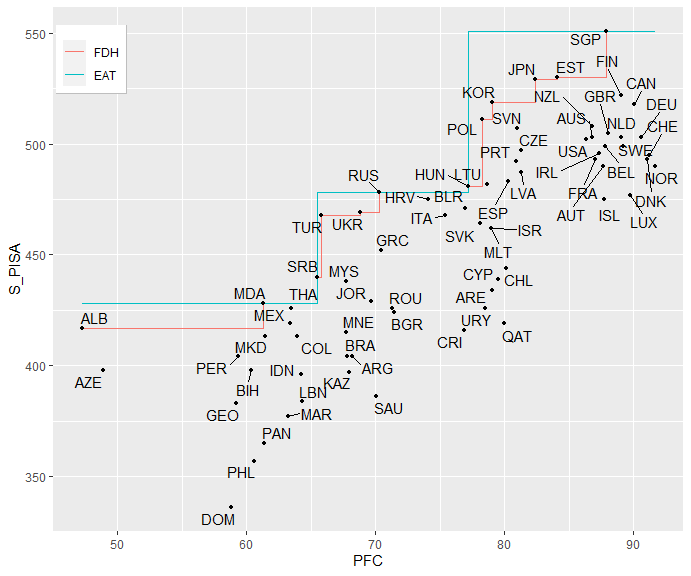

```r
frontier <- frontier(object = single_model,
                     FDH = TRUE,
                     observed.data = TRUE,
                     rwn = TRUE)

plot(frontier)
```

- Is the number of steps on the frontier always the same as the number of leaf nodes?

The answer is no. Note that there may be situations where the estimation of two or more nodes is identical. This is necessary to ensure the estimation of an increasing monotonic frontier. In this case, the number of leaf nodes is 5, however the predictions for nodes 4 and 5 are the same and therefore the border only has 4 steps.

```r
single_model_md <- EAT(data = PISAindex,
                       x = 15, # input
                       y = 3, # output
                       max.leaves = 5)
```

```r
size(single_model_md)
```

```
The number of leaf nodes of the EAT model is: 5
```

```r
single_model_md[["model"]][["y"]]
```

```
     [,1]
[1,]  551
[2,]  478
[3,]  428
[4,]  417
[5,]  417
```

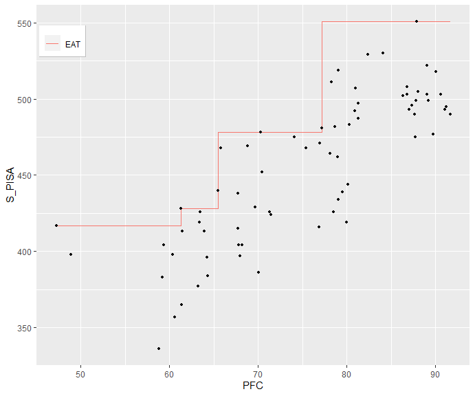

```r
frontier_md <- frontier(object = single_model_md,
                        observed.data = TRUE)

plot(frontier_md)
```

## Modeling a multioutput scenario. Feature selection.

- Example 2: `S_PISA + R_PISA + M_PISA ~ NBMC + WS + S + PS + ABK + AIC + HW + EO + PR + PFC + I + AAE + GDP_PPP`

```r
multioutput_model <- EAT(data = PISAindex,
                         x = 6:18, # input
                         y = 3:5 # output
                         )
```

### rankingEAT()

The second example presents a multiple output scenario where 13 inputs are used to model the 3 available outputs. In these situations, a selection of the most contributing variables may be recommended in order to reduce overfitting, improve precision and reduce future training times. `rankingEAT()` allows a selection of variables by calculating a score of importance through the Efficiency Analysis Trees technique. The user can specify the number of decimal units (`digits`), include a barplot with the scores of importance (`barplot`) and display a horizontal line in the graph to facilitate the cut-off point between important and irrelevant variables (`threshold`).

```r
rankingEAT(object,
           barplot = TRUE,
           threshold = 70,
           digits = 2)
```

The importance score represents how influential each variable is in the model. In this case, the cut-off point is set at 70 and therefore important variables are considered: **AAE** (Acess to Advance Education), **WS** (Water and Sanitation), **NBMC** (Nutrition and Basic Medical Care), **HW** (Health and Wellness) and **S** (Shelter).

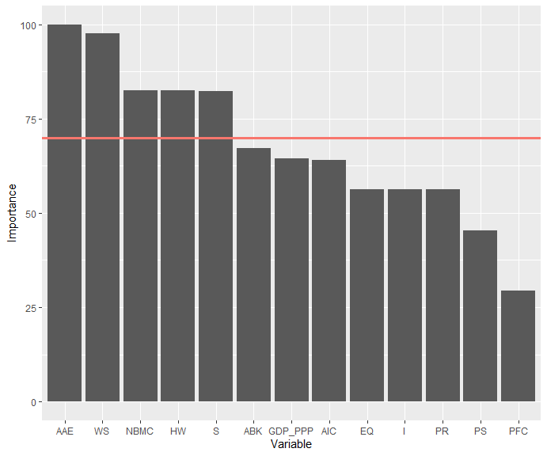

```r
rankingEAT(object = multioutput_model,
           barplot = TRUE,
           threshold = 70,
           digits = 2)
$scores
        Importance
AAE         100.00
WS           97.65
NBMC         82.55
HW           82.49
S            82.24
ABK          67.16
GDP_PPP      64.54
AIC          64.08
EQ           56.29
PR           56.22
I            56.22
PS           45.38
PFC          29.35

$barplot
```

## Graphical representation by a tree structure

### plotEAT()

`frontier()` allows us to clearly see the regions of the input space originated with `EAT()`; however, this is impossible with more than two variables (one input and one output). For multiple input and / or output scenarios, the typical tree-structure showing the relationships between the predicted and predictive variables, is given.

In each node, we can obtain the following information:

- `id`: node index.
- `R`: error at the node.
- `n(t)`: number of DMUs at the node.
- `input name` by which the split take place.
- `y` : vector of predictions.

Furthermore, the nodes are colored according to the variable by which the division is performed or they are black, in the case of being a leaf node.

```r
plotEAT(object)
```

Below are the 3 ways to control the size of a tree model: `numStop`, `max.depth` and `max.leaves`.

- Example 3: `S_PISA + R_PISA + M_PISA ~ NBMC + WS + S + HW + AAE`

Size control by `numStop`

```r
reduced_model1 <- EAT(data = PISAindex,
                      x = c(6, 7, 8, 12, 17), # input
                      y = 3:5, # output
                      numStop = 9)
```

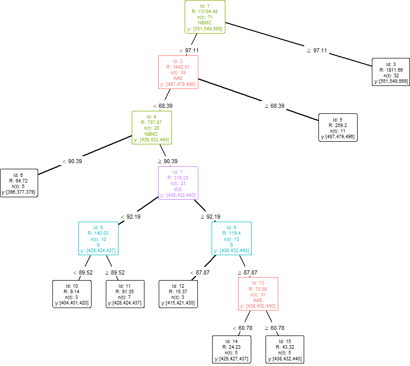

```r
plotEAT(object = reduced_model1)
```

```r
# Leaf nodes: 8
# Depth: 6
```

Size control by `max.depth`

```r
reduced_model2 <- EAT(data = PISAindex,
                      x = c(6, 7, 8, 12, 17), # input
                      y = 3:5, # output
                      numStop = 9,
                      max.depth = 5)
```

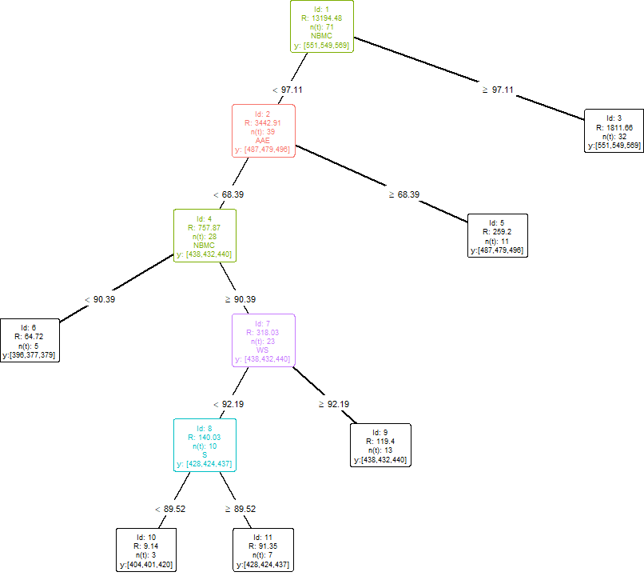

```r
plotEAT(object = reduced_model2)
```

```r
# Leaf nodes: 6
# Depth: 5
```

Size control by `max.leaves`

```r
reduced_model3 <- EAT(data = PISAindex,
                      x = c(6, 7, 8, 12, 17), # input
                      y = 3:5, # output
                      numStop = 9,
                      max.leaves = 4)
```

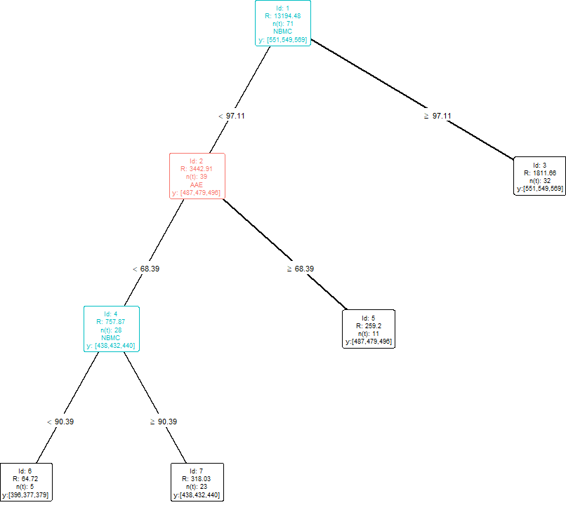

```r
plotEAT(object = reduced_model3)
```

```r
# Leaf nodes: 4
# Depth: 3
```

## EAT tuning

In this section, the `PISAindex` database is divided into a training subset with 70% of the DMUs and a test subset with the remaining 30%. Next, the `bestEAT` function is applied to find the value of the hyperparameters that minimize the error calculated on the test sample from an Efficiency Analysis Trees fitted with the training sample.

```r
n <- nrow(PISAindex) # Observations in the dataset
selected <- sample(1:n, n * 0.7) # Training indexes
training <- PISAindex[selected, ] # Training set
test <- PISAindex[- selected, ] # Test set
```

### bestEAT()

The `bestEAT` function requires a training set (`training`) on which to model an Efficiency Analysis Trees model (with cross-validation) and a test set (`test`) on which to calculate the error. The number of trees built is given by the number of different combinations that can be given by the `numStop`, `fold`, `max.depth` and `max.leaves` arguments. Note that it is not possible to enter `NULL` and a certain value in `max.depth` or `max.leaves` arguments at the same time. `bestEAT()` returns a data frame with the following columns:

- `numStop` : numStop hyperparameter value.
- `fold` : fold hyperparameter value.
- `max.depth` : max.depth hyperparameter value if it does not set to `NULL`.
- `max.leaves` : max.leaves hyperparameter value if it does not set to `NULL`.
- `RMSE`: root mean square error calculated on the test sample with a tree built with the training sample and the set of hyperparameters.
- `leaves`: number of leaf nodes at the tree.

```r
bestEAT(training, test,
        x, y,
        numStop = 5,
        fold = 5,
        max.depth = NULL,
        max.leaves = NULL,
        na.rm = TRUE)
```

For example, if the arguments `numStop = {3, 5, 7}` and `fold = {5, 7}` are entered, 6 models of Efficiency Analysis Trees are constructed with {`numStop = 3`, `fold = 5`}, {`numStop = 3`, `fold = 7`}, {`numStop = 5`, `fold = 5`}, {`numStop = 5`, `fold = 7`}, {`numStop` = 7, `fold = 5`} and {`numStop = 7`, `fold = 7`}.

Tuning for:

`S_PISA + R_PISA + M_PISA ~ NBMC + WS + S + HW + AAE`.

`numStop = {3, 5, 7}` and `fold = {5, 7}`

```r
bestEAT(training = training,
        test = test,
        x = c(6, 7, 8, 12, 17),
        y = 3:5,
        numStop = c(3, 5, 7),
        fold = c(5, 7))
```

```
  numStop fold  RMSE leaves
1       3    7 56.82     24
2       3    5 58.81     13
3       7    5 59.14     10
4       7    7 59.14     10
5       5    7 60.13     12
6       5    5 60.24     11
```

The best Efficiency Analysis Trees is given by the hyperparameters `{numStop = 3, fold = 7}` with `RMSE = 56.82` and 24 leaf nodes. However, this model is too complex. Therefore, we select the model with parameters `{numStop = 7, fold = 5}` with `RMSE = 59.14` but with only 10 leaf nodes. Now we check the results of this model.

```r
bestEAT_model <- EAT(data = PISAindex,
                     x = c(6, 7, 8, 12, 17),
                     y = 3:5,
                     numStop = 7,
                     fold = 5)
```

```r
summary(bestEAT_model)
```

[output not shown]

[output cut: 35 more lines]

```
    AAE --> {R: 128.7, s: 54.17}

 Node 9 --> {12,13} || S --> {R: 94.35, s: 87.87}
   Surrogate splits
    AAE --> {R: 98.11, s: 60.78}
    HW --> {R: 114.28, s: 67.69}
    NBMC --> {R: 114.97, s: 94.49}
    WS --> {R: 115.91, s: 94.63}

 Node 13 --> {14,15} || AAE --> {R: 67.55, s: 60.78}
   Surrogate splits
    S --> {R: 71.15, s: 92.12}
    NBMC --> {R: 74.55, s: 94.49}
    WS --> {R: 75.49, s: 94.63}
    HW --> {R: 76.2, s: 67.69}
```

## Efficiency scores. Graphical representation.

### Efficiency Analysis Trees model: efficiencyEAT()

The efficiency scores are numerical values that indicate the degree of efficiency of a set of DMUs. A dataset (`data`) and the corresponding indexes of input(s) (`x`) and output(s) (`y`) must be entered. It is recommended that the dataset with the DMUs whose efficiency is to be calculated coincide with those used to estimate the frontier. However, it is also possible to calculate the efficiency scores for a new dataset. The efficiency scores are calculated using the mathematical programming model included in the argument `score_model`. The following models are available:

- `BCC.OUT`: Banker Charnes and Cooper output-oriented radial model with efficiency level at 1.
- `BCC.INP`: Banker Charnes and Cooper input-oriented radial model with efficiency level at 1.
- `DDF`: Directional Distance Function with efficiency level at 0.
- `RSL.OUT`: output-oriented Rusell Model with efficiency level at 1.
- `RSL.INP`: input-oriented Rusell Model with efficiency level at 1.
- `WAM.MIP`: Weighted Additive Model with Measure of Inefficiency Proportion. Efficiency level at 0.
- `WAM.RAM`: Weighted Additive Model with Range Adjusted Measure of Inefficiency. Efficiency level at 0.

If `FDH = TRUE`, scores are also calculated through a FDH model. Finally, a brief summary of the distribution of the scores calculated for each model is also included.

For this section, the previously created `single_model` is used:

```r
efficiencyEAT(data, x, y,
              object,
              score_model,
              digits = 3,
              FDH = TRUE,
              na.rm = TRUE)
```

```r
# single_model <- EAT(data = PISAindex,
                    # x = 15,
                    # y = 3)

scores_EAT <- efficiencyEAT(data = PISAindex,
                            x = 15,
                            y = 3,
                            object = single_model,
                            scores_model = "BCC.OUT",
                            digits = 3,
                            FDH = TRUE,
                            na.rm = TRUE)
```

```
    EAT_BCC_OUT FDH_BCC_OUT
SGP       1.000       1.000
JPN       1.042       1.000
KOR       1.062       1.000
EST       1.040       1.000
NLD       1.095       1.095
POL       1.078       1.000
CHE       1.113       1.113
CAN       1.064       1.064
DNK       1.118       1.118
SVN       1.087       1.024
BEL       1.104       1.062
FIN       1.056       1.056
SWE       1.104       1.104
GBR       1.091       1.091
NOR       1.124       1.124
DEU       1.095       1.095
IRL       1.111       1.069
AUT       1.124       1.082
CZE       1.109       1.044
LVA       1.131       1.066
FRA       1.118       1.075
ISL       1.160       1.116
NZL       1.085       1.043
PRT       1.120       1.055
AUS       1.095       1.054
RUS       1.000       1.000
ITA       1.021       1.021
SVK       1.187       1.037
LUX       1.155       1.155
HUN       1.146       1.000
LTU       1.143       1.060
ESP       1.141       1.075
USA       1.098       1.056
BLR       1.015       1.015
MLT       1.193       1.106
HRV       1.006       1.006
ISR       1.193       1.106
TUR       1.021       1.000
UKR       1.019       1.000
```

[output cut: 24 more lines]

```
COL       1.036       1.036
BRA       1.183       1.158
ARG       1.183       1.158
IDN       1.081       1.081
SAU       1.238       1.215
MAR       1.135       1.135
PAN       1.173       1.173
PHL       1.199       1.168
DOM       1.274       1.241

 Model  Mean Std. Dev. Min    Q1 Median   Q3   Max
   EAT 1.114     0.074   1 1.061   1.11 1.11 1.315

 Model  Mean Std. Dev. Min   Q1 Median    Q3   Max
   FDH 1.081     0.065   1 1.03  1.069 1.069 1.241
```

```r
scores_EAT2 <- efficiencyEAT(data = PISAindex,
                             x = 15,
                             y = 3,
                             object = single_model,
                             scores_model = "BCC.INP",
                             digits = 3,
                             FDH = TRUE,
                             na.rm = TRUE)
```

```
    EAT_BCC_INP FDH_BCC_INP
SGP       0.878       1.000
JPN       0.937       1.000
KOR       0.976       1.000
EST       0.918       1.000
NLD       0.867       0.879
POL       0.987       1.000
CHE       0.846       0.858
CAN       0.857       0.878
DNK       0.848       0.859
SVN       0.953       0.966
BEL       0.879       0.891
FIN       0.867       0.925
SWE       0.865       0.877
GBR       0.877       0.889
NOR       0.842       0.854
DEU       0.852       0.863
IRL       0.884       0.896
AUT       0.881       0.893
CZE       0.950       0.963
LVA       0.950       0.963
FRA       0.887       0.899
ISL       0.746       0.801
NZL       0.890       0.902
PRT       0.954       0.967
AUS       0.889       0.901
RUS       0.931       1.000
ITA       0.868       0.873
SVK       0.838       0.843
LUX       0.729       0.783
HUN       1.000       1.000
LTU       0.981       0.995
ESP       0.961       0.974
USA       0.894       0.906
BLR       0.850       0.913
MLT       0.829       0.833
HRV       0.884       0.949
ISR       0.829       0.833
TUR       0.994       1.000
UKR       0.951       1.000
```

[output cut: 24 more lines]

```
COL       0.739       0.739
BRA       0.697       0.697
ARG       0.693       0.693
IDN       0.735       0.735
SAU       0.674       0.674
MAR       0.748       0.748
PAN       0.770       0.770
PHL       0.780       0.780
DOM       0.804       0.804

 Model  Mean Std. Dev.   Min    Q1 Median    Q3 Max
   EAT 0.839     0.105 0.591 0.763  0.851 0.851   1

 Model  Mean Std. Dev.   Min    Q1 Median    Q3 Max
   FDH 0.873       0.1 0.615 0.797  0.878 0.878   1
```

### Convex Efficiency Analysis Trees model: efficiencyCEAT()

`efficiencyCEAT()` returns the efficiency scores for the convex frontier obtained through an Efficiency Analysis Trees model. In this case, if `DEA = TRUE`, scores are also calculated through a DEA model.

```r
efficiencyCEAT(data, x, y,
               object,
               score_model,
               digits = 3,
               DEA = TRUE,
               na.rm = TRUE)
```

```r
scores_CEAT <- efficiencyCEAT(data = PISAindex,
                              x = 15,
                              y = 3,
                              object = single_model,
                              scores_model = "BCC.INP",
                              digits = 3,
                              DEA = TRUE,
                              na.rm = TRUE)
```

```
    CEAT_BCC_INP DEA_BCC_INP
SGP        0.878       1.000
JPN        0.872       0.986
KOR        0.878       0.989
EST        0.857       0.969
NLD        0.736       0.824
POL        0.862       0.968
CHE        0.697       0.777
CAN        0.768       0.865
DNK        0.693       0.772
SVN        0.821       0.920
BEL        0.735       0.821
FIN        0.787       0.888
SWE        0.724       0.809
GBR        0.750       0.840
NOR        0.680       0.757
DEU        0.723       0.809
IRL        0.731       0.816
AUT        0.712       0.792
CZE        0.788       0.880
LVA        0.758       0.843
FRA        0.725       0.808
ISL        0.669       0.739
NZL        0.769       0.862
PRT        0.776       0.865
AUS        0.754       0.845
RUS        0.846       0.936
ITA        0.756       0.832
SVK        0.717       0.787
LUX        0.660       0.729
HUN        0.779       0.864
LTU        0.768       0.851
ESP        0.755       0.838
USA        0.756       0.846
BLR        0.750       0.826
MLT        0.703       0.771
HRV        0.792       0.875
ISR        0.703       0.771
TUR        0.866       0.953
UKR        0.831       0.916
```

[output cut: 24 more lines]

```
COL        0.739       0.739
BRA        0.697       0.697
ARG        0.693       0.693
IDN        0.735       0.735
SAU        0.674       0.674
MAR        0.748       0.748
PAN        0.770       0.770
PHL        0.780       0.780
DOM        0.804       0.804

 Model  Mean Std. Dev.   Min    Q1 Median    Q3 Max
  CEAT 0.749     0.077 0.591 0.698  0.749 0.749   1

 Model  Mean Std. Dev.   Min    Q1 Median    Q3 Max
   DEA 0.805     0.094 0.599 0.739  0.801 0.801   1
```

### efficiencyJitter()

`efficiencyJitter` returns a jitter plot from `ggplot2`. This graphic shows how DMUs are grouped into leaf nodes in a model built using the `EAT` function. Each leaf node groups DMUs with the same level of resources. The dot and the black line represent, respectively, the mean value and the standard deviation of the scores of its node. Additionally, efficient DMU labels are always displayed based on the model entered in the `score_model` argument. Finally, the user can specify an upper bound (`upb`) and a lower bound (`lwb`) in order to show, in addition, the labels whose efficiency score lies between them. Scores from a convex Efficiency Analysis Tree (`CEAT`) model can also be used.

```r
efficiencyJitter(object, df_scores,
                 scores_model,
                 lwb = NULL, upb = NULL)
```

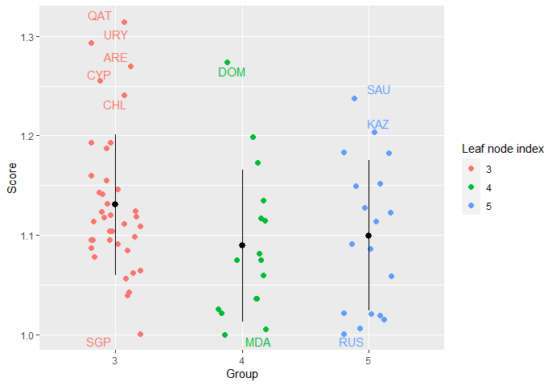

```r
efficiencyJitter(object = single_model,
                 df_scores = scores_EAT$EAT_BCC_OUT,
                 scores_model = "BCC.OUT",
                 lwb = 1.2)
```

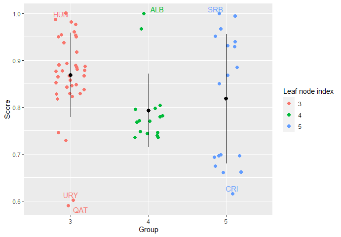

```r
efficiencyJitter(object = single_model,
                 df_scores = scores_EAT2$EAT_BCC_INP,
                 scores_model = "BCC.INP",
                 upb = 0.65)
```

Graphically, for a single input and output scenario it is observed that if the BCC models are used to obtain the efficiency scores:

- Under output orientation, those DMUs that are arranged in the horizontal plane of the frontier are efficient.
- Under input orientation those DMUs that are arranged in the vertical plane of the frontier are efficient.
- If a DMU is located in a corner of the frontier, it is efficient under both orientations.

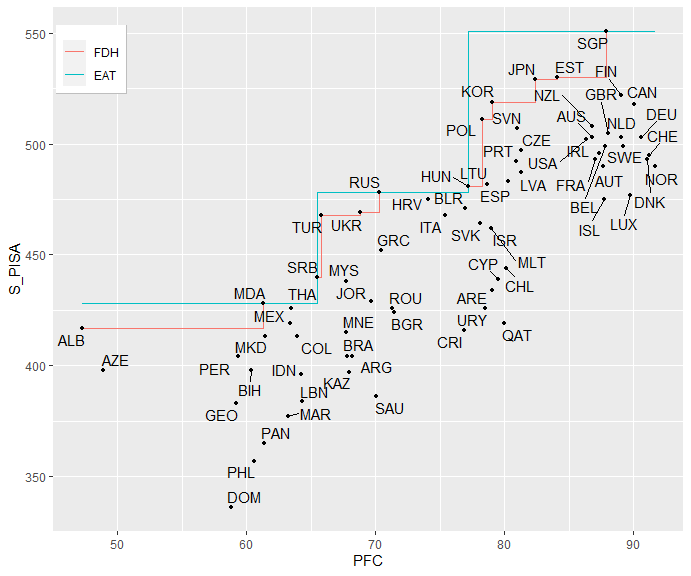

```r
# frontier <- frontier(object = single_model,
                     # FDH = TRUE,
                     # observed.data = TRUE,
                     # rwn = TRUE)

plot(frontier)
```

### efficiencyDensity()

`efficiencyDensity()` returns a density plot from `ggplot2`. In this way, the similarity between the scores obtained by the different available methodologies can be verified.

```r
efficiencyDensity(df_scores,
                  model = c("EAT", "FDH"))
```

In our example:

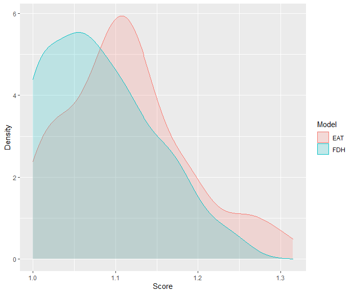

```r
efficiencyDensity(df_scores = scores_EAT[, 3:4],
                  model = c("EAT", "FDH"))
```

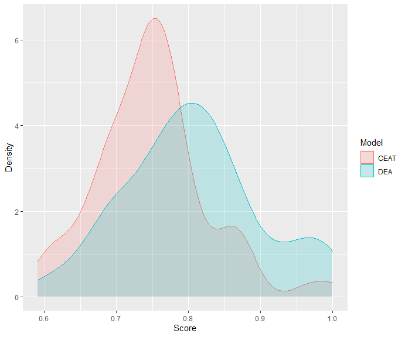

```r
efficiencyDensity(df_scores = scores_CEAT[, 3:4],
                  model = c("CEAT", "DEA"))
```

**The curse of dimensionality**

When the ratio of the sample size and the number of variables (inputs and outputs) is low, the standard methods of efficiency analysis (specially FDH) tend to evaluate a large number of DMUs as technically efficient. This problem is known as the **curse of dimensionality**. To show it, the efficiency scores of the `multioutput_model` (section 2) with 16 variables and 72 DMUs are calculated:

```r
# multioutput_model <- EAT(data = PISAindex,
                         # x = 6:18,
                         # y = 3:5
                         # )

cursed_scores <- efficiencyEAT(data = PISAindex,
                               x = 6:18,
                               y = 3:5,
                               object = multioutput_model,
                               scores_model = "BCC.OUT",
                               digits = 3,
                               FDH = TRUE)
```

```
    EAT_BCC_OUT FDH_BCC_OUT
SGP       1.000       1.000
JPN       1.042       1.000
KOR       1.062       1.000
EST       1.040       1.000
NLD       1.095       1.000
POL       1.072       1.000
CHE       1.105       1.002
CAN       1.056       1.000
DNK       1.096       1.014
SVN       1.087       1.000
BEL       1.104       1.000
FIN       1.056       1.000
SWE       1.085       1.012
GBR       1.089       1.000
NOR       1.100       1.026
DEU       1.095       1.016
IRL       1.060       1.000
AUT       1.124       1.034
CZE       1.109       1.000
LVA       1.000       1.000
FRA       1.114       1.000
ISL       1.149       1.042
NZL       1.085       1.006
PRT       1.116       1.000
AUS       1.091       1.016
RUS       1.013       1.000
ITA       1.153       1.000
SVK       1.021       1.000
LUX       1.155       1.000
HUN       1.006       1.000
LTU       1.006       1.000
USA       1.087       1.000
BLR       1.158       1.000
MLT       1.193       1.000
HRV       1.146       1.000
ISR       1.168       1.000
TUR       1.028       1.000
UKR       1.028       1.000
CYP       1.100       1.000
```

[output cut: 23 more lines]

```
COL       1.019       1.000
BRA       1.017       1.000
ARG       1.192       1.000
IDN       1.000       1.000
SAU       1.000       1.000
MAR       1.030       1.000
PAN       1.000       1.000
PHL       1.074       1.000
DOM       1.102       1.000

 Model Mean Std. Dev. Min    Q1 Median    Q3   Max
   EAT 1.06     0.057   1 1.004  1.047 1.047 1.201

 Model  Mean Std. Dev. Min Q1 Median Q3   Max
   FDH 1.002     0.008   1  1      1  1 1.042
```

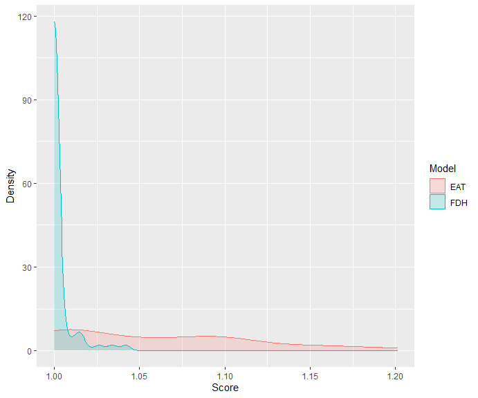

```r
efficiencyDensity(df_scores = cursed_scores[, 17:18],
                  model = c("EAT", "FDH"))
```

## Random Forest

### RFEAT()

Random Forest + Efficiency Analysis Trees (`RFEAT`) has also been developed with the aim of providing a greater stability to the results obtained by the `EAT` function. The `RFEAT` function requires the `data` containing the variables for the analysis, `x` and `y` corresponding to the inputs and outputs indexes respectively, the minimum number of observations in a node for a split to be attempted (`numStop`) and `na.rm` to ignore observations with `NA` cells. All these arguments are used for the construction of the `m` individual Efficiency Analysis Trees that make up the random forest. Finally, the argument `s_mtry` indicates the number of inputs that can be randomly selected in each split. It can be set as any integer although there are also certain predefined values. Being, $n_{x}$ the number of inputs, $n_{y}$ the number of outputs and $n(t)$ the number of observations in a node, the available options in `s_mtry` are:

- `BRM` = $\frac{n_{x}}{3}$
- `DEA1` = $\frac{n(t)}{2} - n_{y}$
- `DEA2` = $\frac{n(t)}{3} - n_{y}$
- `DEA3` = $n(t) - 2 \cdot n_{y}$
- `DEA4` = $min(\frac{n(t)}{n_{y}}, \frac{n(t)}{3} - n_{y})$

The function returns a `RFEAT` object.

```r
RFEAT(data, x, y,
      numStop = 5, m = 50,
      s_mtry = "BRM",
      na.rm = TRUE)
```

```r
forest <- RFEAT(data = PISAindex,
                x = 6:18, # input
                y = 3:5, # output
                numStop = 5,
                m = 30,
                s_mtry = "BRM",
                na.rm = TRUE)
```

```r
print(forest)
```

```
  Formula:  S_PISA + R_PISA + M_PISA ~ NBMC + WS + S + PS + ABK + AIC + HW + EQ + PR + PFC + I + AAE + GDP_PPP

 # ========================== #
 #           Forest           #
 # ========================== #

 Error: 2415.03
 numStop: 5
 No. of trees (m): 30
 No. of inputs tried (s_mtry): BRM
```

## plotRFEAT()

`plotRFEAT()` returns the Out-Of-Bag error for the training dataset and a forest consisting of k trees. Note that the OOB error of early forests suffers from great variability.

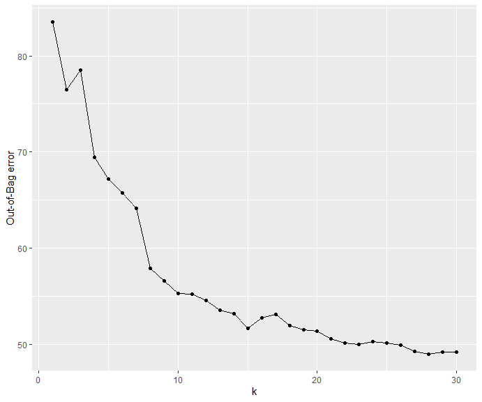

```r
plotRFEAT(forest)
```

## rankingRFEAT()

As in `rankingEAT()`, the `rankingRFEAT` function allows an importance score for variables using a `RFEAT` object to be calculated.

```r
rankingRFEAT(object,
             barplot = TRUE,
             digits = 2,
)
```

For example (this function is usually computationally exhaustive, thus a database reduction is carried out):

```r
forestReduced <- RFEAT(data = PISAindex,
                       x = c(6, 7, 8, 12, 17),
                       y = 3:5,
                       numStop = 5,
                       m = 30,
                       s_mtry = "BRM",
                       na.rm = TRUE)
```

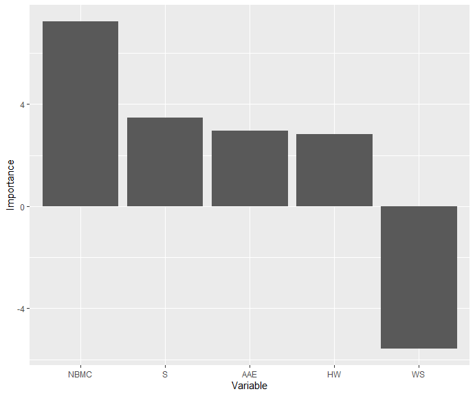

```r
rankingRFEAT(object = forestReduced,
             barplot = TRUE,
             digits = 2)
$scores
     Importance
NBMC   7.252310
S      3.466513
AAE    2.950586
HW     2.829207
WS    -5.584984

$barplot
```

- A positive importance score means that including the input in the model improves the performance.
- A negative importance score means that removing the input from the model improves the performance.

## bestRFEAT()

As in `bestEAT()`, the `bestRFEAT` function is applied to find the optimal hyperparameters that minimize the root mean square error (RMSE) calculated on the test sample. In this case, the available hyperparameters are `numStop`, `m` and `s_mtry`.

```r
bestRFEAT(training, test,
          x, y,
          numStop = 5,
          m = 50,
          s_mtry = c("5", "BRM"),
          na.rm = TRUE)
```

In our example:

```r
# n <- nrow(PISAindex)
# selected <- sample(1:n, n * 0.7)
# training <- PISAindex[selected, ]
# test <- PISAindex[- selected, ]

bestRFEAT(training = training,
          test = test,
          x = c(6, 7, 8, 12, 17),
          y = 3:5,
          numStop = c(5, 10), # set of possible numStop
          m = c(20, 30), # set of possible m
          s_mtry = c("1", "BRM")) # set of possible s_mtry
```

```
  numStop  m s_mtry  RMSE
1       5 20    BRM 54.07
2       5 30    BRM 57.60
3      10 30    BRM 57.88
4      10 20    BRM 58.51
5      10 30      1 60.44
6       5 20      1 64.28
7       5 30      1 65.94
8      10 20      1 68.02
```

```r
bestRFEAT_model <- RFEAT(data = PISAindex,
                         x = c(6, 7, 8, 12, 17),
                         y = 3:5,
                         numStop = 5,
                         m = 20,
                         s_mtry = "BRM")
```

## efficiencyRFEAT()

As in `efficiencyEAT()`, the `efficiencyRFEAT` function returns the efficiency scores for a set of DMUs. However, in this case it is only available for the BCC model with output orientation. Again, the FDH scores can be requested using `FDH = TRUE`.

```r
efficiencyRFEAT(data, x, y,
                object,
                digits = 2,
                FDH = TRUE)
```

In our example:

```r
scoresRF <- efficiencyRFEAT(data = PISAindex,
                            x = c(6, 7, 8, 12, 17), # input
                            y = 3:5, # output
                            object = bestRFEAT_model,
                            FDH = TRUE)
    RFEAT_BCC_OUT FDH_BCC_OUT
SGP         0.949       1.000
JPN         0.989       1.000
KOR         0.998       1.000
EST         0.966       1.000
NLD         1.013       1.000
POL         0.979       1.000
CHE         1.060       1.105
CAN         1.008       1.006
DNK         1.030       1.014
SVN         1.010       1.000
BEL         1.031       1.016
FIN         1.008       1.006
SWE         1.032       1.034
GBR         1.028       1.012
NOR         1.049       1.044
DEU         1.036       1.016
IRL         1.007       1.010
AUT         1.049       1.034
CZE         1.025       1.028
LVA         0.984       1.000
FRA         1.061       1.057
ISL         1.071       1.057
NZL         1.023       1.034
PRT         1.026       1.000
AUS         1.038       1.040
RUS         0.974       1.000
ITA         1.078       1.060
SVK         0.990       1.000
LUX         1.049       1.000
HUN         0.985       1.000
LTU         1.006       1.000
USA         1.015       1.014
BLR         1.004       1.000
MLT         1.031       1.000
HRV         1.003       1.000
ISR         1.074       1.019
TUR         0.996       1.000
UKR         0.959       1.000
CYP         1.097       1.067
GRC         1.111       1.120
SRB         1.010       1.000
MYS         0.987       1.000
ALB         0.968       1.000
BGR         1.012       1.000
ARE         0.989       1.000
MNE         1.032       1.000
ROU         1.003       1.000
KAZ         1.018       1.000
MDA         0.989       1.000
AZE         0.968       1.000
THA         0.984       1.000
URY         1.048       1.000
CHL         1.066       1.060
QAT         1.019       1.000
MEX         1.012       1.000
BIH         1.040       1.000
CRI         1.034       1.000
JOR         1.024       1.000
PER         0.991       1.000
GEO         1.055       1.000
MKD         1.037       1.000
LBN         1.092       1.036
COL         1.050       1.000
BRA         1.042       1.000
ARG         1.149       1.159
IDN         0.970       1.000
SAU         1.055       1.015
MAR         1.016       1.000
PAN         1.060       1.000
PHL         1.045       1.000
DOM         1.080       1.000

 Model  Mean Std. Dev.   Min    Q1 Median    Q3   Max
 RFEAT 1.024     0.038 0.949 0.997  1.023 1.023 1.149

 Model  Mean Std. Dev. Min Q1 Median Q3   Max
   FDH 1.015      0.03   1  1      1  1 1.159
```

## Predictions

`predictEAT()` and `predictRFEAT()` return a data frame with the data and the expected output for a set of observations using Efficiency Analysis Trees and Random Forest + Efficiency Analysis Trees techniques respectively. In both cases, `newdata` refers to a data frame and `x` the set of inputs to be used. Regarding the `object` argument, in the first case it corresponds to an `EAT` object and in the second case to a `RFEAT` object.

In predictions using an `EAT` object, only one Efficiency Analysis Tree is used. However, for the `RFEAT` model, the output is predicted by each of the `m` individual trees trained and subsequently the mean value of all predictions is obtained.

### predictEAT()

```r
predictEAT(object, newdata, x)
```

### predictRFEAT()

```r
predictRFEAT(object, newdata, x)
```

Finally, an example is shown that aims to show the different predictions made by each of the methods (both have been previously defined):

```r
# bestEAT_model <- EAT(data = PISAindex,
                     # x = c(6, 7, 8, 12, 17),
                     # y = 3:5,
                     # numStop = 5,
                     # fold = 5)

# bestRFEAT_model <- EAT(data = PISAindex,
                       # x = c(6, 7, 8, 12, 17),
                       # y = 3:5,
                       # numStop = 3,
                       # m = 30,
                       # s_mtry = 'BRM')

predictions_EAT <- predictEAT(object = bestEAT_model,
                              newdata = PISAindex,
                              x = c(6, 7, 8, 12, 17))

predictions_RFEAT <- predictRFEAT(object = bestRFEAT_model,
                                  newdata = PISAindex,
                                  x = c(6, 7, 8, 12, 17))
```

| S_PISA | R_PISA | M_PISA | S_EAT | R_EAT | M_EAT | S_RFEAT | R_RFEAT | M_RFEAT |
| --- | --- | --- | --- | --- | --- | --- | --- | --- |
| 551 | 549 | 569 | 551 | 549 | 569 | 529.80 | 526.45 | 540.25 |
| 529 | 504 | 527 | 551 | 549 | 569 | 523.05 | 516.00 | 527.15 |
| 519 | 514 | 526 | 551 | 549 | 569 | 521.50 | 518.05 | 524.95 |
| 530 | 523 | 523 | 551 | 549 | 569 | 511.75 | 505.55 | 511.35 |
| 503 | 485 | 519 | 551 | 549 | 569 | 522.05 | 519.55 | 525.85 |
| 511 | 512 | 516 | 551 | 549 | 569 | 504.00 | 501.40 | 508.70 |
| 495 | 484 | 515 | 551 | 549 | 569 | 536.85 | 533.40 | 545.80 |
| 518 | 520 | 512 | 551 | 549 | 569 | 527.50 | 524.05 | 527.35 |
| 493 | 501 | 509 | 551 | 549 | 569 | 521.10 | 518.85 | 524.20 |
| 507 | 495 | 509 | 551 | 549 | 569 | 512.60 | 508.65 | 513.85 |
| 499 | 493 | 508 | 551 | 549 | 569 | 520.10 | 516.95 | 523.50 |
| 522 | 520 | 507 | 551 | 549 | 569 | 527.60 | 524.15 | 526.80 |
| 499 | 506 | 502 | 551 | 549 | 569 | 525.55 | 522.30 | 526.30 |
| 505 | 504 | 502 | 551 | 549 | 569 | 520.55 | 518.10 | 523.55 |
| 490 | 499 | 501 | 551 | 549 | 569 | 527.20 | 523.35 | 528.10 |
| 503 | 498 | 500 | 551 | 549 | 569 | 521.10 | 518.85 | 524.00 |
| 496 | 518 | 500 | 551 | 549 | 569 | 523.95 | 521.50 | 525.45 |
| 490 | 484 | 499 | 551 | 549 | 569 | 520.10 | 516.95 | 523.35 |
| 497 | 490 | 499 | 551 | 549 | 569 | 509.45 | 506.95 | 511.55 |
| 487 | 479 | 496 | 487 | 479 | 496 | 482.35 | 475.80 | 488.00 |
| 493 | 493 | 495 | 551 | 549 | 569 | 526.90 | 523.15 | 529.95 |
| 475 | 474 | 495 | 551 | 549 | 569 | 527.75 | 523.15 | 529.90 |
| 508 | 506 | 494 | 551 | 549 | 569 | 520.55 | 517.55 | 519.20 |
| 492 | 492 | 492 | 551 | 549 | 569 | 508.05 | 504.80 | 511.70 |
| 503 | 503 | 491 | 551 | 549 | 569 | 526.85 | 522.00 | 527.25 |
| 478 | 473 | 488 | 487 | 479 | 496 | 474.85 | 471.10 | 475.20 |
| 468 | 476 | 487 | 551 | 549 | 569 | 521.10 | 518.20 | 524.75 |
| 464 | 458 | 486 | 487 | 479 | 496 | 475.20 | 470.85 | 480.95 |
| 477 | 470 | 483 | 551 | 549 | 569 | 502.95 | 497.70 | 506.75 |
| 481 | 476 | 481 | 487 | 479 | 496 | 474.00 | 470.10 | 478.65 |
| 482 | 476 | 481 | 487 | 479 | 496 | 485.50 | 478.65 | 491.80 |
| 483 | NA | 481 | 551 | 549 | 569 | 524.70 | 521.50 | 526.30 |
| 502 | 505 | 478 | 551 | 549 | 569 | 513.50 | 512.60 | 513.50 |
| 471 | 474 | 472 | 551 | 549 | 569 | 479.45 | 475.75 | 479.70 |
| 462 | 448 | 472 | 551 | 549 | 569 | 480.45 | 475.20 | 486.40 |
| 475 | 479 | 464 | 551 | 549 | 569 | 483.05 | 480.20 | 487.50 |
| 462 | 470 | 463 | 551 | 549 | 569 | 508.45 | 504.90 | 510.45 |
| 468 | 466 | 454 | 469 | 466 | 454 | 466.70 | 463.95 | 456.20 |
| 469 | 466 | 453 | 469 | 466 | 454 | 450.10 | 446.85 | 442.45 |
| 439 | 424 | 451 | 487 | 479 | 496 | 489.30 | 484.80 | 494.60 |
| 452 | 457 | 451 | 551 | 549 | 569 | 509.95 | 507.70 | 512.05 |
| 440 | 439 | 448 | 487 | 479 | 496 | 449.40 | 447.15 | 452.30 |
| 438 | 415 | 440 | 438 | 432 | 440 | 435.70 | 427.05 | 434.25 |
| 417 | 405 | 437 | 428 | 424 | 437 | 415.65 | 405.80 | 423.10 |
| 424 | 420 | 436 | 438 | 432 | 440 | 435.55 | 433.05 | 441.25 |
| 434 | 432 | 435 | 438 | 432 | 440 | 430.90 | 427.45 | 433.25 |
| 415 | 421 | 430 | 415 | 421 | 430 | 439.65 | 436.75 | 443.85 |
| 426 | 428 | 430 | 438 | 432 | 440 | 433.95 | 429.10 | 436.25 |
| 397 | 387 | 423 | 428 | 424 | 437 | 430.70 | 422.25 | 430.65 |
| 428 | 424 | 421 | 428 | 424 | 437 | 424.55 | 419.25 | 427.15 |
| 398 | 389 | 420 | 404 | 401 | 420 | 397.75 | 387.80 | 406.60 |
| 426 | 393 | 419 | 428 | 424 | 437 | 419.00 | 407.05 | 416.95 |
| 426 | 427 | 418 | 429 | 427 | 437 | 450.60 | 447.60 | 450.95 |
| 444 | 452 | 417 | 487 | 479 | 496 | 489.35 | 481.95 | 495.60 |
| 419 | 407 | 414 | 429 | 427 | 437 | 427.00 | 421.85 | 429.95 |
| 419 | 420 | 409 | 429 | 427 | 437 | 431.10 | 424.90 | 429.40 |
| 398 | 403 | 406 | 415 | 421 | 430 | 424.90 | 419.25 | 428.80 |
| 416 | 426 | 402 | 429 | 427 | 437 | 444.30 | 440.45 | 446.10 |
| 429 | 419 | 400 | 429 | 427 | 437 | 439.25 | 432.70 | 437.95 |
| 404 | 401 | 400 | 404 | 401 | 420 | 403.20 | 397.25 | 406.00 |
| 383 | 380 | 398 | 404 | 401 | 420 | 411.50 | 403.40 | 420.00 |
| 413 | 393 | 394 | 415 | 421 | 430 | 428.10 | 423.25 | 434.55 |
| 384 | 353 | 393 | 428 | 424 | 437 | 424.60 | 414.10 | 429.05 |
| 413 | 412 | 391 | 428 | 424 | 437 | 438.75 | 432.50 | 440.00 |
| 404 | 413 | 384 | 428 | 424 | 437 | 432.90 | 430.15 | 431.20 |
| 404 | 402 | 379 | 469 | 466 | 454 | 467.65 | 461.85 | 464.15 |
| 396 | 371 | 379 | 396 | 377 | 379 | 384.00 | 368.40 | 376.15 |
| 386 | 399 | 373 | 438 | 432 | 440 | 429.20 | 420.85 | 431.95 |
| 377 | 359 | 368 | 396 | 377 | 379 | 382.95 | 372.95 | 378.55 |
| 365 | 377 | 353 | 396 | 377 | 379 | 408.85 | 399.55 | 403.65 |
| 357 | 340 | 353 | 396 | 377 | 379 | 376.10 | 360.40 | 368.90 |
| 336 | 342 | 325 | 396 | 377 | 379 | 378.30 | 369.45 | 372.75 |

- Prediction for new observations

```r
new <- data.frame(NBMC = c(90, 95, 93),
                  WS = c(87, 92, 99),
                  S = c(93, 90, 90),
                  HW = c(90, 91, 92),
                  AAE = c(88, 91, 89))

predictions_EAT <- predictEAT(object = bestEAT_model,
                              newdata = new,
                              x = 1:5)
```